# First and second line medication dosing and progression to pediatric refractory status epilepticus

```r
fisher.test(tblALIVE)
```

```
##
##  Fisher's Exact Test for Count Data
##
## data:  tblALIVE
## p-value = 0.00559
## alternative hypothesis: two.sided
```

#Univariate analysis complications and type of AED

```r
CrossTable(pSERG$AEDTYPE, pSERG$intubation)
```

```
##
##
##    Cell Contents
## |-------------------------|
## |                       N |
## | Chi-square contribution |
## |           N / Row Total |
## |           N / Col Total |
## |         N / Table Total |
## |-------------------------|
##
##
## Total Observations in Table:  315
##
##
##               | pSERG$intubation
## pSERG$AEDTYPE |         0 |         1 | Row Total |
## --------------|-----------|-----------|-----------|
##             0 |        63 |        84 |       147 |
##               |     0.161 |     0.132 |           |
##               |     0.429 |     0.571 |     0.467 |
##               |     0.444 |     0.486 |           |
##               |     0.200 |     0.267 |           |
## --------------|-----------|-----------|-----------|
##             1 |        62 |        70 |       132 |
##               |     0.105 |     0.086 |           |
##               |     0.470 |     0.530 |     0.419 |
##               |     0.437 |     0.405 |           |
##               |     0.197 |     0.222 |           |
## --------------|-----------|-----------|-----------|
##             2 |        17 |        19 |        36 |
##               |     0.037 |     0.030 |           |
##               |     0.472 |     0.528 |     0.114 |
##               |     0.120 |     0.110 |           |
##               |     0.054 |     0.060 |           |
## --------------|-----------|-----------|-----------|
##  Column Total |       142 |       173 |       315 |
##               |     0.451 |     0.549 |           |
## --------------|-----------|-----------|-----------|
##
##
```

```r
chisq.test(pSERG$AEDTYPE, pSERG$intubation)
```

```
##
##  Pearson's Chi-squared test
##
## data:  pSERG$AEDTYPE and pSERG$intubation
## X-squared = 0.5505, df = 2, p-value = 0.7594
```

#Bar graph inadequate BZD dose and RSE

```r
#Transform variable inadequate BZD dose into factor
class(pSERG$BZDinadequate10)
```

```
## [1] "numeric"
```

```r
pSERG$BZDinadequate10 <- as.factor(as.numeric(pSERG$BZDinadequate10))
class(pSERG$BZDinadequate10)
```

```
## [1] "factor"
```

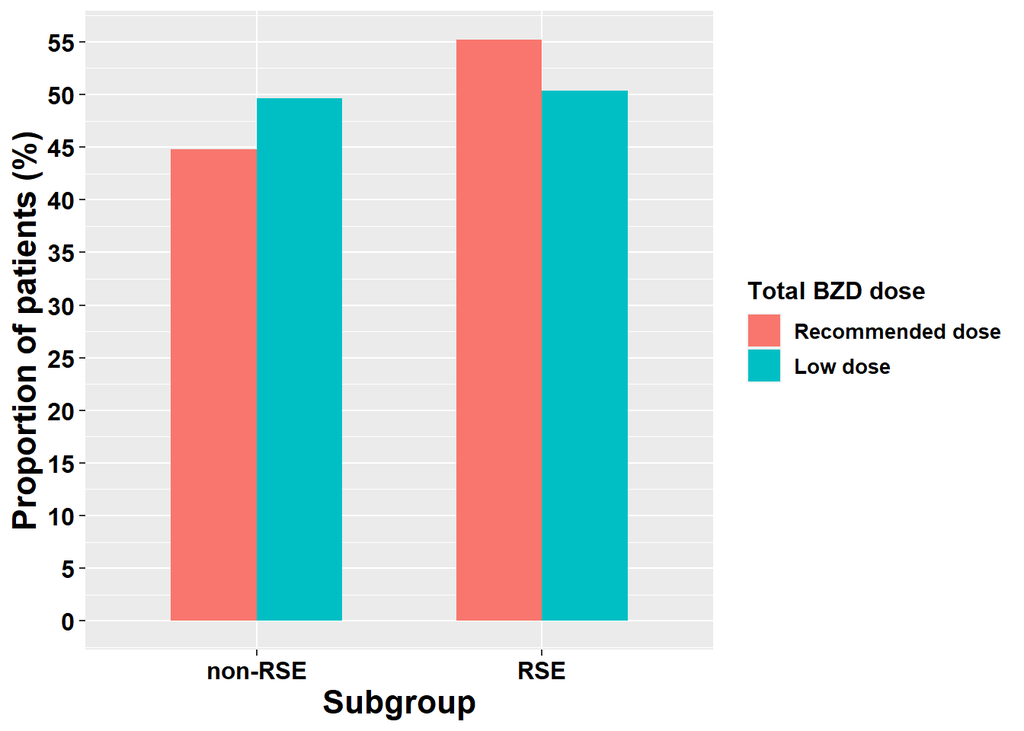

```r
#Transform value into percentages
percent_RSE <- pSERG %>%
    count(SE_GROUP, BZDinadequate10) %>%
    group_by(BZDinadequate10) %>%
    mutate(percent = (n / sum(n)) * 100) %>%
    ungroup()

#Create bar graph comparing BZD dose between subgroups
percent_RSE %>%
    ggplot(aes(x = SE_GROUP, y = percent, fill = BZDinadequate10)) +
    geom_bar(stat = "identity", position = "dodge", width = 0.6) +
    theme(axis.text = element_text(size = 12, color = "black", face = "bold"),
          axis.title = element_text(size = 16, color = "black", face = "bold"),
          legend.text = element_text(colour="black", size = 10, face = "bold"),
          legend.title = element_text(colour="black", size = 12, face = "bold")) +
    scale_x_discrete(labels=c("non-RSE","RSE")) +
    scale_y_continuous(breaks = c(0, 5, 10, 15, 20, 25, 30, 35, 40, 45, 50, 55, 60, 65, 70)) +
    scale_fill_discrete(name="Total BZD dose",labels=c("Recommended dose", "Low dose")) +
    labs(x = "Subgroup", y = "Proportion of patients (%)")
```

#Bar graph inadequate non-BZD ASM dose and RSE

```r
#Transform variable inadequate non-BZD ASM dose into factor
class(pSERG$TOTALAEDinadequateSINGLEDOSE)
```

```
## [1] "numeric"
```

```r
pSERG$TOTALAEDinadequateSINGLEDOSE <- as.factor(as.numeric(pSERG$TOTALAEDinadequateSINGLEDOSE))
class(pSERG$TOTALAEDinadequateSINGLEDOSE)
```

```
## [1] "factor"
```

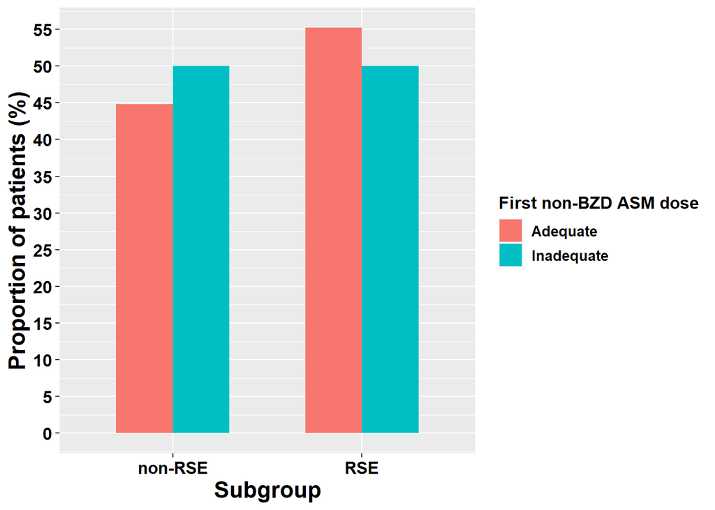

```r
#Transform value into percentages
percent_RSE <- pSERG %>%
    count(SE_GROUP, TOTALAEDinadequateSINGLEDOSE) %>%
    group_by(TOTALAEDinadequateSINGLEDOSE) %>%
    mutate(percent = (n / sum(n)) * 100) %>%
    ungroup()

#Create bar graph comparing non-BZD ASM dose between subgroups
percent_RSE %>%
    ggplot(aes(x = SE_GROUP, y = percent, fill = TOTALAEDinadequateSINGLEDOSE)) +
    geom_bar(stat = "identity", position = "dodge", width = 0.6) +
    theme(axis.text = element_text(size = 12, color = "black", face = "bold"),
          axis.title = element_text(size = 16, color = "black", face = "bold"),
          legend.text = element_text(colour="black", size = 10, face = "bold"),
          legend.title = element_text(colour="black", size = 12, face = "bold")) +
    scale_x_discrete(labels=c("non-RSE","RSE")) +
    scale_y_continuous(breaks = c(0, 5, 10, 15, 20, 25, 30, 35, 40, 45, 50, 55, 60, 65, 70)) +
    scale_fill_discrete(name="First non-BZD ASM dose",labels=c("Adequate", "Inadequate")) +
    labs(x = "Subgroup", y = "Proportion of patients (%)")
```

## Multivariate regression model for the probability of developing RSE and inadequate BZD dose and non-BZD ASM dose as main predictors (OUTCOME= SE GROUP: RSE vs. non-RSE)

```r
#Evaluating multicollinearity in the model using variance inflation factor (vif)
vif(glm((RSE==0)~(BZDinadequate10==1)+(TOTALAEDinadequateSINGLEDOSE==1)+ageyears+male+priorepilepsy+priorSE+STRUCTURALETIOLOGY+INTERMITTENT+BZDTIME.0+AEDTIME.0+HOMEMEDAED+HOSPITALONSET,data=pSERG, family=binomial(link='logit')))
```

```
##              BZDinadequate10 == 1 TOTALAEDinadequateSINGLEDOSE == 1
##                          1.150662                          1.030175
##                          ageyears                              male
##                          1.116927                          1.039714
##                     priorepilepsy                           priorSE
##                          1.904399                          1.224074
##                STRUCTURALETIOLOGY                      INTERMITTENT
##                          1.030204                          1.069659
##                         BZDTIME.0                         AEDTIME.0
##                          1.810468                          1.872975
##                        HOMEMEDAED                     HOSPITALONSET
##                          1.798976                          1.097616
```

```r
#RSE group and inadequate BZD and first non-BZD ASM dose as main predictors
modelf1<-glm((RSE==1)~(TOTALAEDinadequateSINGLEDOSE==1)+BZDinadequate10+ageyears+male+priorepilepsy+priorSE+STRUCTURALETIOLOGY+INTERMITTENT+BZDTIME.0+AEDTIME.0+HOMEMEDAED+HOSPITALONSET,data=pSERG, family=binomial(link='logit'))
summary(modelf1)
```

```
##
## Call:
## glm(formula = (RSE == 1) ~ (TOTALAEDinadequateSINGLEDOSE == 1) +
##     BZDinadequate10 + ageyears + male + priorepilepsy + priorSE +
##     STRUCTURALETIOLOGY + INTERMITTENT + BZDTIME.0 + AEDTIME.0 +
##     HOMEMEDAED + HOSPITALONSET, family = binomial(link = "logit"),
##     data = pSERG)
##
## Deviance Residuals:
##    Min      1Q  Median      3Q     Max
## -1.542  -1.199   0.908   1.115   1.514
##
## Coefficients:
##                                         Estimate Std. Error z value Pr(>|z|)
## (Intercept)                           -0.0871877  0.3260854  -0.267    0.789
## TOTALAEDinadequateSINGLEDOSE == 1TRUE -0.1978856  0.2349195  -0.842    0.400
## BZDinadequate101                      -0.2232222  0.2457875  -0.908    0.364
## ageyears                               0.0004156  0.0228547   0.018    0.985
## male                                   0.2178935  0.2318595   0.940    0.347
## priorepilepsy                          0.1200902  0.3128934   0.384    0.701
## priorSE                               -0.0217082  0.3112623  -0.070    0.944
## STRUCTURALETIOLOGY                    -0.2068040  0.2693970  -0.768    0.443
## INTERMITTENT                           0.2535429  0.2412196   1.051    0.293
## BZDTIME.0                             -0.0016306  0.0016509  -0.988    0.323
## AEDTIME.0                              0.0014470  0.0010638   1.360    0.174
## HOMEMEDAED                            -0.1655038  0.3087492  -0.536    0.592
## HOSPITALONSET                          0.2185872  0.2531731   0.863    0.388
##
## (Dispersion parameter for binomial family taken to be 1)
##
##     Null deviance: 442.36  on 319  degrees of freedom
## Residual deviance: 434.59  on 307  degrees of freedom
## AIC: 460.59
##
## Number of Fisher Scoring iterations: 4
```

```r
exp(coef(modelf1))
```

```
##                           (Intercept) TOTALAEDinadequateSINGLEDOSE == 1TRUE
##                             0.9165051                             0.8204637
##                      BZDinadequate101                              ageyears
##                             0.7999371                             1.0004157
##                                  male                         priorepilepsy
##                             1.2434546                             1.1275986
##                               priorSE                    STRUCTURALETIOLOGY
##                             0.9785258                             0.8131790
##                          INTERMITTENT                             BZDTIME.0
##                             1.2885826                             0.9983707
##                             AEDTIME.0                            HOMEMEDAED
##                             1.0014481                             0.8474667
##                         HOSPITALONSET
##                             1.2443175
```

```r
exp(cbind(OddsRatio=coef(modelf1),confint(modelf1)))
```

```
##                                       OddsRatio     2.5 %   97.5 %
## (Intercept)                           0.9165051 0.4815076 1.736025
## TOTALAEDinadequateSINGLEDOSE == 1TRUE 0.8204637 0.5171933 1.300565
## BZDinadequate101                      0.7999371 0.4932300 1.294658
## ageyears                              1.0004157 0.9565200 1.046429
## male                                  1.2434546 0.7899198 1.962471
## priorepilepsy                         1.1275986 0.6106642 2.091476
## priorSE                               0.9785258 0.5310713 1.805541
## STRUCTURALETIOLOGY                    0.8131790 0.4785843 1.379587
## INTERMITTENT                          1.2885826 0.8033631 2.070782
## BZDTIME.0                             0.9983707 0.9949135 1.001582
## AEDTIME.0                             1.0014481 0.9996251 1.003873
## HOMEMEDAED                            0.8474667 0.4603584 1.550914
## HOSPITALONSET                         1.2443175 0.7588753 2.050925
```

##Secondary analysis only with patients who received LEV

```r
#Subset of patients who received LEV as first dose of second line treatment
pSERGLEV <- subset(pSERG, pSERG$FIRSTLEV==1)
dim(pSERGLEV)
```

```
## [1]  134 1754
```

```r
#Summary of first dose of levetiracetam
summary(pSERGLEV$AEDDOSE.0KG)
```

```
##    Min. 1st Qu.  Median    Mean 3rd Qu.    Max.
##  0.0823 19.9333 29.7257 30.9780 41.6234 67.3469
```

```r
#Create variable for patients who received LEV dose within recommendations and divide them into 2 groups: lower range (20-40 mg/kg) and higher range (41-60 mg/kg)
pSERGLEV$lowrangeLEV[pSERGLEV$AEDDOSE.0KG>=41 & pSERGLEV$AEDDOSE.0KG<=60] <- 0
pSERGLEV$lowrangeLEV[pSERGLEV$AEDDOSE.0KG>=20 & pSERGLEV$AEDDOSE.0KG<=40] <- 1

CrossTable(pSERGLEV$lowrangeLEV)
```

```
##
##
##    Cell Contents
## |-------------------------|
## |                       N |
## |         N / Table Total |
## |-------------------------|
##
##
## Total Observations in Table:  90
##
##
##           |         0 |         1 |
##           |-----------|-----------|
##           |        29 |        61 |
##           |     0.322 |     0.678 |
##           |-----------|-----------|
##
##
##
##
```

```r
#Summary of first dose of levetiracetam when in the range 20-60 mg/kg
summary(pSERGLEV[which(pSERGLEV$lowrangeLEV==1 | pSERGLEV$lowrangeLEV==0),]$AEDDOSE.0KG)
```

```
##    Min. 1st Qu.  Median    Mean 3rd Qu.    Max.
##   20.00   26.22   30.37   35.00   43.25   60.00
```

```r
#Summary of first dose of levetiracetam when in the range 20-40 mg/kg
summary(pSERGLEV[which(pSERGLEV$lowrangeLEV==1),]$AEDDOSE.0KG)
```

```
##    Min. 1st Qu.  Median    Mean 3rd Qu.    Max.
##   20.00   21.82   29.63   28.29   30.56   40.00
```

```r
#Summary of first dose of levetiracetam when in the range 41-60 mg/kg
summary(pSERGLEV[which(pSERGLEV$lowrangeLEV==0),]$AEDDOSE.0KG)
```

```
##    Min. 1st Qu.  Median    Mean 3rd Qu.    Max.
##   41.24   44.38   47.55   49.13   53.57   60.00
```

#Univariate analysis

```r
CrossTable(pSERGLEV$lowrangeLEV, pSERGLEV$RSE)
```

```
##
##
##    Cell Contents
## |-------------------------|
## |                       N |
## | Chi-square contribution |
## |           N / Row Total |
## |           N / Col Total |
## |         N / Table Total |
## |-------------------------|
##
##
## Total Observations in Table:  90
##
##
##                      | pSERGLEV$RSE
## pSERGLEV$lowrangeLEV |         0 |         1 | Row Total |
## ---------------------|-----------|-----------|-----------|
##                    0 |        13 |        16 |        29 |
##                      |     0.169 |     0.113 |           |
##                      |     0.448 |     0.552 |     0.322 |
##                      |     0.361 |     0.296 |           |
##                      |     0.144 |     0.178 |           |
## ---------------------|-----------|-----------|-----------|
##                    1 |        23 |        38 |        61 |
##                      |     0.080 |     0.054 |           |
##                      |     0.377 |     0.623 |     0.678 |
##                      |     0.639 |     0.704 |           |
##                      |     0.256 |     0.422 |           |
## ---------------------|-----------|-----------|-----------|
##         Column Total |        36 |        54 |        90 |
##                      |     0.400 |     0.600 |           |
## ---------------------|-----------|-----------|-----------|
##
##
```

```r
# Lower dose range of LEV in RSE patients
CrossTable(pSERGLEV[which(pSERGLEV$RSE==1),]$lowrangeLEV)
```

```
##
##
##    Cell Contents
## |-------------------------|
## |                       N |
## |         N / Table Total |
## |-------------------------|
##
##
## Total Observations in Table:  54
##
##
##           |         0 |         1 |
##           |-----------|-----------|
##           |        16 |        38 |
##           |     0.296 |     0.704 |
##           |-----------|-----------|
##
##
##
##
```

```r
# Lower dose range of LEV in non-RSE patients
CrossTable(pSERGLEV[which(pSERGLEV$RSE==0),]$lowrangeLEV)
```

```
##
##
##    Cell Contents
## |-------------------------|
## |                       N |
## |         N / Table Total |
## |-------------------------|
##
##
## Total Observations in Table:  36
##
##
##           |         0 |         1 |
##           |-----------|-----------|
##           |        13 |        23 |
##           |     0.361 |     0.639 |
##           |-----------|-----------|
##
##
##
##
```

```r
# Univariate analysis RSE patients and lower/higher dose range
chisq.test(pSERGLEV$lowrangeLEV, pSERGLEV$RSE)
```

```
##
##  Pearson's Chi-squared test with Yates' continuity correction
##
## data:  pSERGLEV$lowrangeLEV and pSERGLEV$RSE
## X-squared = 0.17171, df = 1, p-value = 0.6786
```

##Multivariate regression model for the probability of developing a RSE and low or high dose group of LEV as main predictor.

```r
#RSE group and inadequate first AED dose without interaction term
modelf2<-glm((RSE==1)~(lowrangeLEV==1)+BZDinadequate10+ageyears+male+STRUCTURALETIOLOGY+BZDTIME.0+AEDTIME.0+HOMEMEDLEV,data=pSERGLEV, family=binomial(link='logit'))
summary(modelf2)
```

```
##
## Call:
## glm(formula = (RSE == 1) ~ (lowrangeLEV == 1) + BZDinadequate10 +
##     ageyears + male + STRUCTURALETIOLOGY + BZDTIME.0 + AEDTIME.0 +
##     HOMEMEDLEV, family = binomial(link = "logit"), data = pSERGLEV)
##
## Deviance Residuals:
##     Min       1Q   Median       3Q      Max
## -1.9014  -1.2417   0.7894   0.9770   1.6481
##
## Coefficients:
##                       Estimate Std. Error z value Pr(>|z|)
## (Intercept)          -0.163190   0.586025  -0.278    0.781
## lowrangeLEV == 1TRUE  0.422129   0.482471   0.875    0.382
## BZDinadequate101     -0.521195   0.478801  -1.089    0.276
## ageyears              0.050504   0.048292   1.046    0.296
## male                  0.175392   0.470438   0.373    0.709
## STRUCTURALETIOLOGY   -0.027927   0.510806  -0.055    0.956
## BZDTIME.0            -0.005894   0.003901  -1.511    0.131
## AEDTIME.0             0.003006   0.002628   1.144    0.253
## HOMEMEDLEV            0.050405   0.503475   0.100    0.920
##
## (Dispersion parameter for binomial family taken to be 1)
##
##     Null deviance: 121.14  on 89  degrees of freedom
## Residual deviance: 115.15  on 81  degrees of freedom
##   (44 observations deleted due to missingness)
## AIC: 133.15
##
## Number of Fisher Scoring iterations: 4
```

```r
exp(coef(modelf2))
```

```
##          (Intercept) lowrangeLEV == 1TRUE     BZDinadequate101
##            0.8494299            1.5252056            0.5938108
##             ageyears                 male   STRUCTURALETIOLOGY
##            1.0518014            1.1917128            0.9724589
##            BZDTIME.0            AEDTIME.0           HOMEMEDLEV
##            0.9941234            1.0030109            1.0516972
```

```r
exp(cbind(OddsRatio=coef(modelf2),confint(modelf2)))
```

```
##                      OddsRatio     2.5 %   97.5 %
## (Intercept)          0.8494299 0.2654596 2.700827
## lowrangeLEV == 1TRUE 1.5252056 0.5898469 3.959157
## BZDinadequate101     0.5938108 0.2286036 1.513005
## ageyears             1.0518014 0.9590477 1.161274
## male                 1.1917128 0.4708475 3.009948
## STRUCTURALETIOLOGY   0.9724589 0.3588266 2.706232
## BZDTIME.0            0.9941234 0.9848869 1.001023
## AEDTIME.0            1.0030109 0.9986327 1.009728
## HOMEMEDLEV           1.0516972 0.3902720 2.850250
```

## Secondary outcome: inadequate first nonBZD ASM

#Univariate analysis comparing inadequate vs. adequate first non-BZD ASM dose groups

```r
#Demographics and clinical characteristics
#Continuous variables (Wilcoxon rank sum)

# Age in patients with inadequate first non-BZD ASM dose
nobs(pSERG[pSERG$TOTALAEDinadequateSINGLEDOSE==1, ]$ageyears)
```

```
## [1] 128
```

```r
summary(pSERG[pSERG$TOTALAEDinadequateSINGLEDOSE==1, ]$ageyears)
```

```
##     Min.  1st Qu.   Median     Mean  3rd Qu.     Max.
##  0.08333  1.66667  5.08333  6.50760 10.52083 21.78333
```

```r
sd(pSERG[pSERG$TOTALAEDinadequateSINGLEDOSE==1, ]$ageyears)
```

```
## [1] 5.34572
```

```r
# Age in patients with adequate first non-BZD ASM dose
nobs(pSERG[pSERG$TOTALAEDinadequateSINGLEDOSE==0, ]$ageyears)
```

```
## [1] 192
```

```r
summary(pSERG[pSERG$TOTALAEDinadequateSINGLEDOSE==0, ]$ageyears)
```

```
##    Min. 1st Qu.  Median    Mean 3rd Qu.    Max.
##   0.250   1.667   4.229   6.072   9.500  18.417
```

```r
sd(pSERG[pSERG$TOTALAEDinadequateSINGLEDOSE==0, ]$ageyears)
```

```
## [1] 5.199662
```

```r
wilcox.test(pSERG$ageyears ~ pSERG$TOTALAEDinadequateSINGLEDOSE)
```

```
##
##  Wilcoxon rank sum test with continuity correction
##
## data:  pSERG$ageyears by pSERG$TOTALAEDinadequateSINGLEDOSE
## W = 11731, p-value = 0.4925
## alternative hypothesis: true location shift is not equal to 0
```

```r
# Weight in patients with inadequate first non-BZD ASM dose
nobs(pSERG[pSERG$TOTALAEDinadequateSINGLEDOSE==1, ]$WEIGHT)
```

```
## [1] 128
```

```r
summary(pSERG[pSERG$TOTALAEDinadequateSINGLEDOSE==1, ]$WEIGHT)
```

```
##    Min. 1st Qu.  Median    Mean 3rd Qu.    Max.
##    3.10   12.22   18.50   27.50   37.50   97.70
```

```r
sd(pSERG[pSERG$TOTALAEDinadequateSINGLEDOSE==1, ]$WEIGHT)
```

```
## [1] 21.37689
```

```r
# Weight in patients with adequate first non-BZD ASM dose
nobs(pSERG[pSERG$TOTALAEDinadequateSINGLEDOSE==0, ]$WEIGHT)
```

```
## [1] 192
```

```r
summary(pSERG[pSERG$TOTALAEDinadequateSINGLEDOSE==0, ]$WEIGHT)
```

```
##    Min. 1st Qu.  Median    Mean 3rd Qu.    Max.
##    5.50   10.88   16.15   23.23   28.23   97.00
```

```r
sd(pSERG[pSERG$TOTALAEDinadequateSINGLEDOSE==0, ]$WEIGHT)
```

```
## [1] 18.31353
```

```r
wilcox.test(pSERG$WEIGHT ~ pSERG$TOTALAEDinadequateSINGLEDOSE)
```

```
##
##  Wilcoxon rank sum test with continuity correction
##
## data:  pSERG$WEIGHT by pSERG$TOTALAEDinadequateSINGLEDOSE
## W = 10744, p-value = 0.05687
## alternative hypothesis: true location shift is not equal to 0
```

```r
#Time to first BZD in patients with inadequate first non-BZD ASM dose
nobs(pSERG[pSERG$TOTALAEDinadequateSINGLEDOSE==1, ]$BZDTIME.0)
```

```
## [1] 128
```

```r
summary(pSERG[pSERG$TOTALAEDinadequateSINGLEDOSE==1, ]$BZDTIME.0)
```

```
##    Min. 1st Qu.  Median    Mean 3rd Qu.    Max.
##    0.00    6.00   15.00   34.98   36.25  370.00
```

```r
sd(pSERG[pSERG$TOTALAEDinadequateSINGLEDOSE==1, ]$BZDTIME.0)
```

```
## [1] 61.28743
```

```r
#Time to first BZD in patients with adequate first non-BZD ASM dose
nobs(pSERG[pSERG$TOTALAEDinadequateSINGLEDOSE==0, ]$BZDTIME.0)
```

```
## [1] 192
```

```r
summary(pSERG[pSERG$TOTALAEDinadequateSINGLEDOSE==0, ]$BZDTIME.0)
```

```
##    Min. 1st Qu.  Median    Mean 3rd Qu.    Max.
##    0.00    5.00   15.00   41.33   33.50 1132.00
```

```r
sd(pSERG[pSERG$TOTALAEDinadequateSINGLEDOSE==0, ]$BZDTIME.0)
```

```
## [1] 107.195
```

```r
wilcox.test(pSERG$BZDTIME.0 ~ pSERG$TOTALAEDinadequateSINGLEDOSE)
```

```
##
##  Wilcoxon rank sum test with continuity correction
##
## data:  pSERG$BZDTIME.0 by pSERG$TOTALAEDinadequateSINGLEDOSE
## W = 11742, p-value = 0.5003
## alternative hypothesis: true location shift is not equal to 0
```

```r
#Time to first non-BZD ASM in patients with inadequate first non-BZD ASM dose
nobs(pSERG[pSERG$TOTALAEDinadequateSINGLEDOSE==1, ]$AEDTIME.0)
```

```
## [1] 128
```

```r
summary(pSERG[pSERG$TOTALAEDinadequateSINGLEDOSE==1, ]$AEDTIME.0)
```

```
##    Min. 1st Qu.  Median    Mean 3rd Qu.    Max.
##    14.0    38.0    61.0   120.1   116.2  1488.0
```

```r
sd(pSERG[pSERG$TOTALAEDinadequateSINGLEDOSE==1, ]$AEDTIME.0)
```

```
## [1] 196.8353
```

```r
#Time to first non-BZD ASM in patients with adequate first non-BZD ASM dose
nobs(pSERG[pSERG$TOTALAEDinadequateSINGLEDOSE==0, ]$AEDTIME.0)
```

```
## [1] 192
```

```r
summary(pSERG[pSERG$TOTALAEDinadequateSINGLEDOSE==0, ]$AEDTIME.0)
```

```
##    Min. 1st Qu.  Median    Mean 3rd Qu.    Max.
##    5.00   38.75   72.00  113.67  119.25 1276.00
```

```r
sd(pSERG[pSERG$TOTALAEDinadequateSINGLEDOSE==0, ]$AEDTIME.0)
```

```
## [1] 149.5212
```

```r
wilcox.test(pSERG$AEDTIME.0 ~ pSERG$TOTALAEDinadequateSINGLEDOSE)
```

```
##
##  Wilcoxon rank sum test with continuity correction
##
## data:  pSERG$AEDTIME.0 by pSERG$TOTALAEDinadequateSINGLEDOSE
## W = 12642, p-value = 0.6624
## alternative hypothesis: true location shift is not equal to 0
```

```r
#Categorical predictors (Chi2)
# Sex in patients with inadequate first non-BZD ASM dose
CrossTable(pSERG[pSERG$TOTALAEDinadequateSINGLEDOSE==1, ]$male)
```

```
##
##
##    Cell Contents
## |-------------------------|
## |                       N |
## |         N / Table Total |
## |-------------------------|
##
##
## Total Observations in Table:  128
##
##
##           |         0 |         1 |
##           |-----------|-----------|
##           |        54 |        74 |
##           |     0.422 |     0.578 |
##           |-----------|-----------|
##
##
##
##
```

```r
# Sex in patients with adequate first non-BZD ASM dose
CrossTable(pSERG[pSERG$TOTALAEDinadequateSINGLEDOSE==0, ]$male)
```

```
##
##
##    Cell Contents
## |-------------------------|
## |                       N |
## |         N / Table Total |
## |-------------------------|
##
##
## Total Observations in Table:  192
##
##
##           |         0 |         1 |
##           |-----------|-----------|
##           |        93 |        99 |
##           |     0.484 |     0.516 |
##           |-----------|-----------|
##
##
##
##
```

```r
chisq.test(pSERG$male,pSERG$TOTALAEDinadequateSINGLEDOSE)
```

```
##
##  Pearson's Chi-squared test with Yates' continuity correction
##
## data:  pSERG$male and pSERG$TOTALAEDinadequateSINGLEDOSE
## X-squared = 0.96942, df = 1, p-value = 0.3248
```

```r
# History of epilepsy in patients with inadequate first non-BZD ASM dose
CrossTable(pSERG[pSERG$TOTALAEDinadequateSINGLEDOSE==1, ]$priorepilepsy)
```

```
##
##
##    Cell Contents
## |-------------------------|
## |                       N |
## |         N / Table Total |
## |-------------------------|
##
##
## Total Observations in Table:  128
##
##
##           |         0 |         1 |
##           |-----------|-----------|
##           |        64 |        64 |
##           |     0.500 |     0.500 |
##           |-----------|-----------|
##
##
##
##
```

```r
# History of epilepsy in patients with adequate first non-BZD ASM dose
CrossTable(pSERG[pSERG$TOTALAEDinadequateSINGLEDOSE==0, ]$priorepilepsy)
```

```
##
##
##    Cell Contents
## |-------------------------|
## |                       N |
## |         N / Table Total |
## |-------------------------|
##
##
## Total Observations in Table:  192
##
##
##           |         0 |         1 |
##           |-----------|-----------|
##           |        97 |        95 |
##           |     0.505 |     0.495 |
##           |-----------|-----------|
##
##
##
##
```

```r
chisq.test(pSERG$priorepilepsy,pSERG$TOTALAEDinadequateSINGLEDOSE)
```

```
##
##  Pearson's Chi-squared test with Yates' continuity correction
##
## data:  pSERG$priorepilepsy and pSERG$TOTALAEDinadequateSINGLEDOSE
## X-squared = 1.8358e-30, df = 1, p-value = 1
```

```r
# History of dev delay in patients with inadequate first non-BZD ASM dose
CrossTable(pSERG[pSERG$TOTALAEDinadequateSINGLEDOSE==1, ]$delay)
```

```
##
##
##    Cell Contents
## |-------------------------|
## |                       N |
## |         N / Table Total |
## |-------------------------|
##
##
## Total Observations in Table:  128
##
##
##           |         0 |         1 |
##           |-----------|-----------|
##           |        66 |        62 |
##           |     0.516 |     0.484 |
##           |-----------|-----------|
##
##
##
##
```

```r
# History of dev delay in patients with adequate first non-BZD ASM dose
CrossTable(pSERG[pSERG$TOTALAEDinadequateSINGLEDOSE==0, ]$delay)
```

```
##
##
##    Cell Contents
## |-------------------------|
## |                       N |
## |         N / Table Total |
## |-------------------------|
##
##
## Total Observations in Table:  192
##
##
##           |         0 |         1 |
##           |-----------|-----------|
##           |        88 |       104 |
##           |     0.458 |     0.542 |
##           |-----------|-----------|
##
##
##
##
```

```r
chisq.test(pSERG$delay,pSERG$TOTALAEDinadequateSINGLEDOSE)
```

```
##
##  Pearson's Chi-squared test with Yates' continuity correction
##
## data:  pSERG$delay and pSERG$TOTALAEDinadequateSINGLEDOSE
## X-squared = 0.7933, df = 1, p-value = 0.3731
```

```r
# Prior status
CrossTable(pSERG$priorSE)
```

```
##
##
##    Cell Contents
## |-------------------------|
## |                       N |
## |         N / Table Total |
## |-------------------------|
##
##
## Total Observations in Table:  320
##
##
##           |         0 |         1 |
##           |-----------|-----------|
##           |       255 |        65 |
##           |     0.797 |     0.203 |
##           |-----------|-----------|
##
##
##
##
```

```r
# Prior status in patients with inadequate first non-BZD ASM dose
CrossTable(pSERG[pSERG$TOTALAEDinadequateSINGLEDOSE==1, ]$priorSE)
```

```
##
##
##    Cell Contents
## |-------------------------|
## |                       N |
## |         N / Table Total |
## |-------------------------|
##
##
## Total Observations in Table:  128
##
##
##           |         0 |         1 |
##           |-----------|-----------|
##           |       100 |        28 |
##           |     0.781 |     0.219 |
##           |-----------|-----------|
##
##
##
##
```

```r
# Prior status in patients with adequate first non-BZD ASM dose
CrossTable(pSERG[pSERG$TOTALAEDinadequateSINGLEDOSE==0, ]$priorSE)
```

```
##
##
##    Cell Contents
## |-------------------------|
## |                       N |
## |         N / Table Total |
## |-------------------------|
##
##
## Total Observations in Table:  192
##
##
##           |         0 |         1 |
##           |-----------|-----------|
##           |       155 |        37 |
##           |     0.807 |     0.193 |
##           |-----------|-----------|
##
##
##
##
```

```r
chisq.test(pSERG$priorSE,pSERG$TOTALAEDinadequateSINGLEDOSE)
```

```
##
##  Pearson's Chi-squared test with Yates' continuity correction
##
## data:  pSERG$priorSE and pSERG$TOTALAEDinadequateSINGLEDOSE
## X-squared = 0.181, df = 1, p-value = 0.6705
```

```r
# Structural etiology in patients with inadequate first non-BZD ASM dose
CrossTable(pSERG[pSERG$TOTALAEDinadequateSINGLEDOSE==1, ]$STRUCTURALETIOLOGY)
```

```
##
##
##    Cell Contents
## |-------------------------|
## |                       N |
## |         N / Table Total |
## |-------------------------|
##
##
## Total Observations in Table:  128
##
##
##           |         0 |         1 |
##           |-----------|-----------|
##           |       100 |        28 |
##           |     0.781 |     0.219 |
##           |-----------|-----------|
##
##
##
##
```

```r
# Structural etiology in patients with adequate first non-BZD ASM dose
CrossTable(pSERG[pSERG$TOTALAEDinadequateSINGLEDOSE==0, ]$STRUCTURALETIOLOGY)
```

```
##
##
##    Cell Contents
## |-------------------------|
## |                       N |
## |         N / Table Total |
## |-------------------------|
##
##
## Total Observations in Table:  192
##
##
##           |         0 |         1 |
##           |-----------|-----------|
##           |       144 |        48 |
##           |     0.750 |     0.250 |
##           |-----------|-----------|
##
##
##
##
```

```r
chisq.test(pSERG$STRUCTURALETIOLOGY,pSERG$TOTALAEDinadequateSINGLEDOSE)
```

```
##
##  Pearson's Chi-squared test with Yates' continuity correction
##
## data:  pSERG$STRUCTURALETIOLOGY and pSERG$TOTALAEDinadequateSINGLEDOSE
## X-squared = 0.25956, df = 1, p-value = 0.6104
```

```r
# Genetic etiology in patients with inadequate first non-BZD ASM dose
CrossTable(pSERG[pSERG$TOTALAEDinadequateSINGLEDOSE==1, ]$GENETICETIOLOGY)
```

```
##
##
##    Cell Contents
## |-------------------------|
## |                       N |
## |         N / Table Total |
## |-------------------------|
##
##
## Total Observations in Table:  128
##
##
##           |         0 |         1 |
##           |-----------|-----------|
##           |       104 |        24 |
##           |     0.812 |     0.188 |
##           |-----------|-----------|
##
##
##
##
```

```r
# Genetic etiology in patients with adequate first non-BZD ASM dose
CrossTable(pSERG[pSERG$TOTALAEDinadequateSINGLEDOSE==0, ]$GENETICETIOLOGY)
```

```
##
##
##    Cell Contents
## |-------------------------|
## |                       N |
## |         N / Table Total |
## |-------------------------|
##
##
## Total Observations in Table:  192
##
##
##           |         0 |         1 |
##           |-----------|-----------|
##           |       156 |        36 |
##           |     0.812 |     0.188 |
##           |-----------|-----------|
##
##
##
##
```

```r
chisq.test(pSERG$GENETICETIOLOGY,pSERG$TOTALAEDinadequateSINGLEDOSE)
```

```
##
##  Pearson's Chi-squared test
##
## data:  pSERG$GENETICETIOLOGY and pSERG$TOTALAEDinadequateSINGLEDOSE
## X-squared = 0, df = 1, p-value = 1
```

```r
# Metabolic etiology in patients with inadequate first non-BZD ASM dose
CrossTable(pSERG[pSERG$TOTALAEDinadequateSINGLEDOSE==1, ]$METABOLICETIOLOGY)
```

```
##
##
##    Cell Contents
## |-------------------------|
## |                       N |
## |         N / Table Total |
## |-------------------------|
##
##
## Total Observations in Table:  128
##
##
##           |         0 |         1 |
##           |-----------|-----------|
##           |       124 |         4 |
##           |     0.969 |     0.031 |
##           |-----------|-----------|
##
##
##
##
```

```r
# Genetic etiology in patients with adequate first non-BZD ASM dose
CrossTable(pSERG[pSERG$TOTALAEDinadequateSINGLEDOSE==0, ]$METABOLICETIOLOGY)
```

```
##
##
##    Cell Contents
## |-------------------------|
## |                       N |
## |         N / Table Total |
## |-------------------------|
##
##
## Total Observations in Table:  192
##
##
##           |         0 |         1 |
##           |-----------|-----------|
##           |       186 |         6 |
##           |     0.969 |     0.031 |
##           |-----------|-----------|
##
##
##
##
```

```r
fisher.test(pSERG$METABOLICETIOLOGY,pSERG$TOTALAEDinadequateSINGLEDOSE)
```

```
##
##  Fisher's Exact Test for Count Data
##
## data:  pSERG$METABOLICETIOLOGY and pSERG$TOTALAEDinadequateSINGLEDOSE
## p-value = 1
## alternative hypothesis: true odds ratio is not equal to 1
## 95 percent confidence interval:
##  0.2033022 4.3152079
## sample estimates:
## odds ratio
##          1
```

```r
# Unknown etiology in patients with inadequate first non-BZD ASM dose
CrossTable(pSERG[pSERG$TOTALAEDinadequateSINGLEDOSE==1, ]$UNKETIOLOGY)
```

```
##
##
##    Cell Contents
## |-------------------------|
## |                       N |
## |         N / Table Total |
## |-------------------------|
##
##
## Total Observations in Table:  128
##
##
##           |         0 |         1 |
##           |-----------|-----------|
##           |        76 |        52 |
##           |     0.594 |     0.406 |
##           |-----------|-----------|
##
##
##
##
```

```r
# Unknown etiology in patients with adequate first non-BZD ASM dose
CrossTable(pSERG[pSERG$TOTALAEDinadequateSINGLEDOSE==0, ]$UNKETIOLOGY)
```

```
##
##
##    Cell Contents
## |-------------------------|
## |                       N |
## |         N / Table Total |
## |-------------------------|
##
##
## Total Observations in Table:  192
##
##
##           |         0 |         1 |
##           |-----------|-----------|
##           |       112 |        80 |
##           |     0.583 |     0.417 |
##           |-----------|-----------|
##
##
##
##
```

```r
chisq.test(pSERG$UNKETIOLOGY,pSERG$TOTALAEDinadequateSINGLEDOSE)
```

```
##
##  Pearson's Chi-squared test with Yates' continuity correction
##
## data:  pSERG$UNKETIOLOGY and pSERG$TOTALAEDinadequateSINGLEDOSE
## X-squared = 0.0048356, df = 1, p-value = 0.9446
```

```r
# Other etiology in patients with inadequate first non-BZD ASM dose
CrossTable(pSERG[pSERG$TOTALAEDinadequateSINGLEDOSE==1, ]$OTHERETIOLOGY)
```

```
##
##
##    Cell Contents
## |-------------------------|
## |                       N |
## |         N / Table Total |
## |-------------------------|
##
##
## Total Observations in Table:  128
##
##
##           |         0 |         1 |
##           |-----------|-----------|
##           |       109 |        19 |
##           |     0.852 |     0.148 |
##           |-----------|-----------|
##
##
##
##
```

```r
# Other etiology in patients with adequate first non-BZD ASM dose
CrossTable(pSERG[pSERG$TOTALAEDinadequateSINGLEDOSE==0, ]$OTHERETIOLOGY)
```

```
##
##
##    Cell Contents
## |-------------------------|
## |                       N |
## |         N / Table Total |
## |-------------------------|
##
##
## Total Observations in Table:  192
##
##
##           |         0 |         1 |
##           |-----------|-----------|
##           |       170 |        22 |
##           |     0.885 |     0.115 |
##           |-----------|-----------|
##
##
##
##
```

```r
chisq.test(pSERG$OTHERETIOLOGY,pSERG$TOTALAEDinadequateSINGLEDOSE)
```

```
##
##  Pearson's Chi-squared test with Yates' continuity correction
##
## data:  pSERG$OTHERETIOLOGY and pSERG$TOTALAEDinadequateSINGLEDOSE
## X-squared = 0.51403, df = 1, p-value = 0.4734
```

```r
# Febrile cause in patients with inadequate first non-BZD ASM dose
CrossTable(pSERG[pSERG$TOTALAEDinadequateSINGLEDOSE==1, ]$Febrile_cause)
```

```
##
##
##    Cell Contents
## |-------------------------|
## |                       N |
## |         N / Table Total |
## |-------------------------|
##
##
## Total Observations in Table:  128
##
##
##           |         0 |         1 |
##           |-----------|-----------|
##           |       112 |        16 |
##           |     0.875 |     0.125 |
##           |-----------|-----------|
##
##
##
##
```

```r
# Febrile cause in patients with adequate first non-BZD ASM dose
CrossTable(pSERG[pSERG$TOTALAEDinadequateSINGLEDOSE==0, ]$Febrile_cause)
```

```
##
##
##    Cell Contents
## |-------------------------|
## |                       N |
## |         N / Table Total |
## |-------------------------|
##
##
## Total Observations in Table:  192
##
##
##           |         0 |         1 |
##           |-----------|-----------|
##           |       165 |        27 |
##           |     0.859 |     0.141 |
##           |-----------|-----------|
##
##
##
##
```

```r
chisq.test(pSERG$Febrile_cause,pSERG$TOTALAEDinadequateSINGLEDOSE)
```

```
##
##  Pearson's Chi-squared test with Yates' continuity correction
##
## data:  pSERG$Febrile_cause and pSERG$TOTALAEDinadequateSINGLEDOSE
## X-squared = 0.054851, df = 1, p-value = 0.8148
```

```r
# SE type in patients with inadequate first non-BZD ASM dose
CrossTable(pSERG[pSERG$TOTALAEDinadequateSINGLEDOSE==1, ]$INTERMITTENT)
```

```
##
##
##    Cell Contents
## |-------------------------|
## |                       N |
## |         N / Table Total |
## |-------------------------|
##
##
## Total Observations in Table:  128
##
##
##           |         0 |         1 |
##           |-----------|-----------|
##           |        51 |        77 |
##           |     0.398 |     0.602 |
##           |-----------|-----------|
##
##
##
##
```

```r
# SE type in patients with adequate first non-BZD ASM dose
CrossTable(pSERG[pSERG$TOTALAEDinadequateSINGLEDOSE==0, ]$INTERMITTENT)
```

```
##
##
##    Cell Contents
## |-------------------------|
## |                       N |
## |         N / Table Total |
## |-------------------------|
##
##
## Total Observations in Table:  192
##
##
##           |         0 |         1 |
##           |-----------|-----------|
##           |        70 |       122 |
##           |     0.365 |     0.635 |
##           |-----------|-----------|
##
##
##
##
```

```r
chisq.test(pSERG$INTERMITTENT,pSERG$TOTALAEDinadequateSINGLEDOSE)
```

```
##
##  Pearson's Chi-squared test with Yates' continuity correction
##
## data:  pSERG$INTERMITTENT and pSERG$TOTALAEDinadequateSINGLEDOSE
## X-squared = 0.2442, df = 1, p-value = 0.6212
```

```r
# First line dosing (inadequate BZD dose)
CrossTable(pSERG$BZDinadequate10,pSERG$TOTALAEDinadequateSINGLEDOSE)
```

```
##
##
##    Cell Contents
## |-------------------------|
## |                       N |
## | Chi-square contribution |
## |           N / Row Total |
## |           N / Col Total |
## |         N / Table Total |
## |-------------------------|
##
##
## Total Observations in Table:  320
##
##
##                       | pSERG$TOTALAEDinadequateSINGLEDOSE
## pSERG$BZDinadequate10 |         0 |         1 | Row Total |
## ----------------------|-----------|-----------|-----------|
##                     0 |       118 |        65 |       183 |
##                       |     0.612 |     0.919 |           |
##                       |     0.645 |     0.355 |     0.572 |
##                       |     0.615 |     0.508 |           |
##                       |     0.369 |     0.203 |           |
## ----------------------|-----------|-----------|-----------|
##                     1 |        74 |        63 |       137 |
##                       |     0.818 |     1.227 |           |
##                       |     0.540 |     0.460 |     0.428 |
##                       |     0.385 |     0.492 |           |
##                       |     0.231 |     0.197 |           |
## ----------------------|-----------|-----------|-----------|
##          Column Total |       192 |       128 |       320 |
##                       |     0.600 |     0.400 |           |
## ----------------------|-----------|-----------|-----------|
##
##
```

```r
# First line dosing (inadequate BZD dose) in patients with inadequate first non-BZD ASM dose
CrossTable(pSERG[pSERG$TOTALAEDinadequateSINGLEDOSE==1, ]$BZDinadequate10)
```

```
##
##
##    Cell Contents
## |-------------------------|
## |                       N |
## |         N / Table Total |
## |-------------------------|
##
##
## Total Observations in Table:  128
##
##
##           |         0 |         1 |
##           |-----------|-----------|
##           |        65 |        63 |
##           |     0.508 |     0.492 |
##           |-----------|-----------|
##
##
##
##
```

```r
# First line dosing (inadequate BZD dose) in patients with adequate first non-BZD ASM dose
CrossTable(pSERG[pSERG$TOTALAEDinadequateSINGLEDOSE==0, ]$BZDinadequate10)
```

```
##
##
##    Cell Contents
## |-------------------------|
## |                       N |
## |         N / Table Total |
## |-------------------------|
##
##
## Total Observations in Table:  192
##
##
##           |         0 |         1 |
##           |-----------|-----------|
##           |       118 |        74 |
##           |     0.615 |     0.385 |
##           |-----------|-----------|
##
##
##
##
```

```r
chisq.test(pSERG$BZDinadequate10,pSERG$TOTALAEDinadequateSINGLEDOSE)
```

```
##
##  Pearson's Chi-squared test with Yates' continuity correction
##
## data:  pSERG$BZDinadequate10 and pSERG$TOTALAEDinadequateSINGLEDOSE
## X-squared = 3.1532, df = 1, p-value = 0.07578
```

```r
# Hospital SE onset in patients with inadequate first non-BZD ASM dose
CrossTable(pSERG[pSERG$TOTALAEDinadequateSINGLEDOSE==1, ]$HOSPITALONSET)
```

```
##
##
##    Cell Contents
## |-------------------------|
## |                       N |
## |         N / Table Total |
## |-------------------------|
##
##
## Total Observations in Table:  128
##
##
##           |         0 |         1 |
##           |-----------|-----------|
##           |        87 |        41 |
##           |     0.680 |     0.320 |
##           |-----------|-----------|
##
##
##
##
```

```r
# Hospital SE onset in patients with adequate first non-BZD ASM dose
CrossTable(pSERG[pSERG$TOTALAEDinadequateSINGLEDOSE==0, ]$HOSPITALONSET)
```

```
##
##
##    Cell Contents
## |-------------------------|
## |                       N |
## |         N / Table Total |
## |-------------------------|
##
##
## Total Observations in Table:  192
##
##
##           |         0 |         1 |
##           |-----------|-----------|
##           |       127 |        65 |
##           |     0.661 |     0.339 |
##           |-----------|-----------|
##
##
##
##
```

```r
chisq.test(pSERG$HOSPITALONSET,pSERG$TOTALAEDinadequateSINGLEDOSE)
```

```
##
##  Pearson's Chi-squared test with Yates' continuity correction
##
## data:  pSERG$HOSPITALONSET and pSERG$TOTALAEDinadequateSINGLEDOSE
## X-squared = 0.047611, df = 1, p-value = 0.8273
```

```r
# Home medication with any oral AED in patients with inadequate first non-BZD ASM dose
CrossTable(pSERG[pSERG$TOTALAEDinadequateSINGLEDOSE==1, ]$HOMEMEDAED)
```

```
##
##
##    Cell Contents
## |-------------------------|
## |                       N |
## |         N / Table Total |
## |-------------------------|
##
##
## Total Observations in Table:  128
##
##
##           |         0 |         1 |
##           |-----------|-----------|
##           |        71 |        57 |
##           |     0.555 |     0.445 |
##           |-----------|-----------|
##
##
##
##
```

```r
# Home medication with any oral AED in patients with adequate first non-BZD ASM dose
CrossTable(pSERG[pSERG$TOTALAEDinadequateSINGLEDOSE==0, ]$HOMEMEDAED)
```

```
##
##
##    Cell Contents
## |-------------------------|
## |                       N |
## |         N / Table Total |
## |-------------------------|
##
##
## Total Observations in Table:  192
##
##
##           |         0 |         1 |
##           |-----------|-----------|
##           |       117 |        75 |
##           |     0.609 |     0.391 |
##           |-----------|-----------|
##
##
##
##
```

```r
chisq.test(pSERG$HOMEMEDAED,pSERG$TOTALAEDinadequateSINGLEDOSE)
```

```
##
##  Pearson's Chi-squared test with Yates' continuity correction
##
## data:  pSERG$HOMEMEDAED and pSERG$TOTALAEDinadequateSINGLEDOSE
## X-squared = 0.73555, df = 1, p-value = 0.3911
```

```r
#Clinical outcomes
#Continuous variables ( Wilcoxon rank sum)

#Seizure duration
summary(pSERG$SEIZUREDURATIONHR)
```

```
##     Min.  1st Qu.   Median     Mean  3rd Qu.     Max.     NA's
##    0.000    1.008    1.983   30.096    5.000 1512.000        5
```

```r
#Seizure duration in patients with inadequate first non-BZD ASM dose
nobs(pSERG[pSERG$TOTALAEDinadequateSINGLEDOSE==1, ]$SEIZUREDURATIONHR)
```

```
## [1] 127
```

```r
summary(pSERG[pSERG$TOTALAEDinadequateSINGLEDOSE==1, ]$SEIZUREDURATIONHR)
```

```
##      Min.   1st Qu.    Median      Mean   3rd Qu.      Max.      NA's
##    0.0083    1.0500    1.9833   40.6311    5.2750 1440.0000         1
```

```r
sd(pSERG[pSERG$TOTALAEDinadequateSINGLEDOSE==1, ]$SEIZUREDURATIONHR)
```

```
## [1] NA
```

```r
#Seizure duration in patients with adequate first non-BZD ASM dose
nobs(pSERG[pSERG$TOTALAEDinadequateSINGLEDOSE==0, ]$SEIZUREDURATIONHR)
```

```
## [1] 188
```

```r
summary(pSERG[pSERG$TOTALAEDinadequateSINGLEDOSE==0, ]$SEIZUREDURATIONHR)
```

```
##     Min.  1st Qu.   Median     Mean  3rd Qu.     Max.     NA's
##    0.000    1.000    1.983   22.979    4.521 1512.000        4
```

```r
sd(pSERG[pSERG$TOTALAEDinadequateSINGLEDOSE==0, ]$SEIZUREDURATIONHR)
```

```
## [1] NA
```

```r
wilcox.test(pSERG$SEIZUREDURATIONHR ~ pSERG$TOTALAEDinadequateSINGLEDOSE)
```

```
##
##  Wilcoxon rank sum test with continuity correction
##
## data:  pSERG$SEIZUREDURATIONHR by pSERG$TOTALAEDinadequateSINGLEDOSE
## W = 11870, p-value = 0.9327
## alternative hypothesis: true location shift is not equal to 0
```

```r
#Convulsive duration
summary(pSERG$convulsivedurationmin)
```

```
##    Min. 1st Qu.  Median    Mean 3rd Qu.    Max.    NA's
##     0.0    48.5    90.0  1102.3   188.5 90720.0       9
```

```r
#Convulsive duration in patients with inadequate first non-BZD ASM dose
nobs(pSERG[pSERG$TOTALAEDinadequateSINGLEDOSE==1, ]$convulsivedurationmin)
```

```
## [1] 124
```

```r
summary(pSERG[pSERG$TOTALAEDinadequateSINGLEDOSE==1, ]$convulsivedurationmin)
```

```
##    Min. 1st Qu.  Median    Mean 3rd Qu.    Max.    NA's
##     0.0    50.0    90.0  1357.6   205.5 86400.0       4
```

```r
sd(pSERG[pSERG$TOTALAEDinadequateSINGLEDOSE==1, ]$convulsivedurationmin)
```

```
## [1] NA
```

```r
#Convulsive duration in patients with adequate first non-BZD ASM dose
nobs(pSERG[pSERG$TOTALAEDinadequateSINGLEDOSE==0, ]$convulsivedurationmin)
```

```
## [1] 187
```

```r
summary(pSERG[pSERG$TOTALAEDinadequateSINGLEDOSE==0, ]$convulsivedurationmin)
```

```
##    Min. 1st Qu.  Median    Mean 3rd Qu.    Max.    NA's
##     0.0    45.5    98.0   933.0   180.0 90720.0       5
```

```r
sd(pSERG[pSERG$TOTALAEDinadequateSINGLEDOSE==0, ]$convulsivedurationmin)
```

```
## [1] NA
```

```r
wilcox.test(pSERG$convulsivedurationmin ~ pSERG$TOTALAEDinadequateSINGLEDOSE)
```

```
##
##  Wilcoxon rank sum test with continuity correction
##
## data:  pSERG$convulsivedurationmin by pSERG$TOTALAEDinadequateSINGLEDOSE
## W = 11612, p-value = 0.982
## alternative hypothesis: true location shift is not equal to 0
```

```r
#ICU duration
summary(pSERG$ICU_DURATIONdays)
```

```
##     Min.  1st Qu.   Median     Mean  3rd Qu.     Max.     NA's
##   0.1321   1.0000   2.0729   9.0330   7.3513 121.0000       58
```

```r
#ICU duration in patients with inadequate first non-BZD ASM dose
nobs(pSERG[pSERG$TOTALAEDinadequateSINGLEDOSE==1, ]$ICU_DURATIONdays)
```

```
## [1] 104
```

```r
summary(pSERG[pSERG$TOTALAEDinadequateSINGLEDOSE==1, ]$ICU_DURATIONdays)
```

```
##     Min.  1st Qu.   Median     Mean  3rd Qu.     Max.     NA's
##   0.4167   1.0000   3.0000  10.5999   8.0000 121.0000       24
```

```r
sd(pSERG[pSERG$TOTALAEDinadequateSINGLEDOSE==1, ]$ICU_DURATIONdays)
```

```
## [1] NA
```

```r
#ICU duration in patients with adequate first non-BZD ASM dose
nobs(pSERG[pSERG$TOTALAEDinadequateSINGLEDOSE==0, ]$ICU_DURATIONdays)
```

```
## [1] 158
```

```r
summary(pSERG[pSERG$TOTALAEDinadequateSINGLEDOSE==0, ]$ICU_DURATIONdays)
```

```
##    Min. 1st Qu.  Median    Mean 3rd Qu.    Max.    NA's
##  0.1321  1.0000  2.0000  8.0016  7.0000 73.0000      34
```

```r
sd(pSERG[pSERG$TOTALAEDinadequateSINGLEDOSE==0, ]$ICU_DURATIONdays)
```

```
## [1] NA
```

```r
wilcox.test(pSERG$ICU_DURATIONdays ~ pSERG$TOTALAEDinadequateSINGLEDOSE)
```

```
##
##  Wilcoxon rank sum test with continuity correction
##
## data:  pSERG$ICU_DURATIONdays by pSERG$TOTALAEDinadequateSINGLEDOSE
## W = 7670.5, p-value = 0.3628
## alternative hypothesis: true location shift is not equal to 0
```

```r
#Categorical variables (Chi square test/fisher's exact test)
# SE group (refractory vs non-refractory SE)
CrossTable(pSERG$RSE,pSERG$TOTALAEDinadequateSINGLEDOSE)
```

```
##
##
##    Cell Contents
## |-------------------------|
## |                       N |
## | Chi-square contribution |
## |           N / Row Total |
## |           N / Col Total |
## |         N / Table Total |
## |-------------------------|
##
##
## Total Observations in Table:  320
##
##
##              | pSERG$TOTALAEDinadequateSINGLEDOSE
##    pSERG$RSE |         0 |         1 | Row Total |
## -------------|-----------|-----------|-----------|
##            0 |        86 |        64 |       150 |
##              |     0.178 |     0.267 |           |
##              |     0.573 |     0.427 |     0.469 |
##              |     0.448 |     0.500 |           |
##              |     0.269 |     0.200 |           |
## -------------|-----------|-----------|-----------|
##            1 |       106 |        64 |       170 |
##              |     0.157 |     0.235 |           |
##              |     0.624 |     0.376 |     0.531 |
##              |     0.552 |     0.500 |           |
##              |     0.331 |     0.200 |           |
## -------------|-----------|-----------|-----------|
## Column Total |       192 |       128 |       320 |
##              |     0.600 |     0.400 |           |
## -------------|-----------|-----------|-----------|
##
##
```

```r
# SE group (refractory vs non-refractory SE) in patients with inadequate first non-BZD ASM dose
CrossTable(pSERG[pSERG$TOTALAEDinadequateSINGLEDOSE==1, ]$RSE)
```

```
##
##
##    Cell Contents
## |-------------------------|
## |                       N |
## |         N / Table Total |
## |-------------------------|
##
##
## Total Observations in Table:  128
##
##
##           |         0 |         1 |
##           |-----------|-----------|
##           |        64 |        64 |
##           |     0.500 |     0.500 |
##           |-----------|-----------|
##
##
##
##
```

```r
# SE group (refractory vs non-refractory SE) in patients with adequate first non-BZD ASM dose
CrossTable(pSERG[pSERG$TOTALAEDinadequateSINGLEDOSE==0, ]$RSE)
```

```
##
##
##    Cell Contents
## |-------------------------|
## |                       N |
## |         N / Table Total |
## |-------------------------|
##
##
## Total Observations in Table:  192
##
##
##           |         0 |         1 |
##           |-----------|-----------|
##           |        86 |       106 |
##           |     0.448 |     0.552 |
##           |-----------|-----------|
##
##
##
##
```

```r
chisq.test(pSERG$RSE,pSERG$TOTALAEDinadequateSINGLEDOSE)
```

```
##
##  Pearson's Chi-squared test with Yates' continuity correction
##
## data:  pSERG$RSE and pSERG$TOTALAEDinadequateSINGLEDOSE
## X-squared = 0.64052, df = 1, p-value = 0.4235
```

```r
# Requirement of continuous infusion in patients with inadequate first non-BZD ASM dose
CrossTable(pSERG[pSERG$TOTALAEDinadequateSINGLEDOSE==1, ]$CONTINF)
```

```
##
##
##    Cell Contents
## |-------------------------|
## |                       N |
## |         N / Table Total |
## |-------------------------|
##
##
## Total Observations in Table:  128
##
##
##           |         0 |         1 |
##           |-----------|-----------|
##           |        93 |        35 |
##           |     0.727 |     0.273 |
##           |-----------|-----------|
##
##
##
##
```

```r
# Requirement of continuous infusion in patients with adequate first non-BZD ASM dose
CrossTable(pSERG[pSERG$TOTALAEDinadequateSINGLEDOSE==0, ]$CONTINF)
```

```
##
##
##    Cell Contents
## |-------------------------|
## |                       N |
## |         N / Table Total |
## |-------------------------|
##
##
## Total Observations in Table:  192
##
##
##           |         0 |         1 |
##           |-----------|-----------|
##           |       127 |        65 |
##           |     0.661 |     0.339 |
##           |-----------|-----------|
##
##
##
##
```

```r
chisq.test(pSERG$CONTINF,pSERG$TOTALAEDinadequateSINGLEDOSE)
```

```
##
##  Pearson's Chi-squared test with Yates' continuity correction
##
## data:  pSERG$CONTINF and pSERG$TOTALAEDinadequateSINGLEDOSE
## X-squared = 1.2273, df = 1, p-value = 0.2679
```

```r
# Requirement of intubation in patients with inadequate first non-BZD ASM dose
CrossTable(pSERG[pSERG$TOTALAEDinadequateSINGLEDOSE==1, ]$intubation)
```

```
##
##
##    Cell Contents
## |-------------------------|
## |                       N |
## |         N / Table Total |
## |-------------------------|
##
##
## Total Observations in Table:  125
##
##
##           |         0 |         1 |
##           |-----------|-----------|
##           |        57 |        68 |
##           |     0.456 |     0.544 |
##           |-----------|-----------|
##
##
##
##
```

```r
# Requirement of intubation in patients with adequate first non-BZD ASM dose
CrossTable(pSERG[pSERG$TOTALAEDinadequateSINGLEDOSE==0, ]$intubation)
```

```
##
##
##    Cell Contents
## |-------------------------|
## |                       N |
## |         N / Table Total |
## |-------------------------|
##
##
## Total Observations in Table:  190
##
##
##           |         0 |         1 |
##           |-----------|-----------|
##           |        85 |       105 |
##           |     0.447 |     0.553 |
##           |-----------|-----------|
##
##
##
##
```

```r
chisq.test(pSERG$intubation,pSERG$TOTALAEDinadequateSINGLEDOSE)
```

```
##
##  Pearson's Chi-squared test with Yates' continuity correction
##
## data:  pSERG$intubation and pSERG$TOTALAEDinadequateSINGLEDOSE
## X-squared = 0.0012181, df = 1, p-value = 0.9722
```

```r
# Hypotension in patients with inadequate first non-BZD ASM dose
CrossTable(pSERG[pSERG$TOTALAEDinadequateSINGLEDOSE==1, ]$hypo)
```

```
##
##
##    Cell Contents
## |-------------------------|
## |                       N |
## |         N / Table Total |
## |-------------------------|
##
##
## Total Observations in Table:  125
##
##
##           |         0 |         1 |
##           |-----------|-----------|
##           |        99 |        26 |
##           |     0.792 |     0.208 |
##           |-----------|-----------|
##
##
##
##
```

```r
# Hypotension in patients with adequate first non-BZD ASM dose
CrossTable(pSERG[pSERG$TOTALAEDinadequateSINGLEDOSE==0, ]$hypo)
```

```
##
##
##    Cell Contents
## |-------------------------|
## |                       N |
## |         N / Table Total |
## |-------------------------|
##
##
## Total Observations in Table:  190
##
##
##           |         0 |         1 |
##           |-----------|-----------|
##           |       148 |        42 |
##           |     0.779 |     0.221 |
##           |-----------|-----------|
##
##
##
##
```

```r
chisq.test(pSERG$hypo,pSERG$TOTALAEDinadequateSINGLEDOSE)
```

```
##
##  Pearson's Chi-squared test with Yates' continuity correction
##
## data:  pSERG$hypo and pSERG$TOTALAEDinadequateSINGLEDOSE
## X-squared = 0.018365, df = 1, p-value = 0.8922
```

```r
# Return to baseline function in patients with inadequate first non-BZD ASM dose
CrossTable(pSERG[pSERG$TOTALAEDinadequateSINGLEDOSE==1, ]$baseline)
```

```
##
##
##    Cell Contents
## |-------------------------|
## |                       N |
## |         N / Table Total |
## |-------------------------|
##
##
## Total Observations in Table:  128
##
##
##           |         0 |         1 |
##           |-----------|-----------|
##           |        28 |       100 |
##           |     0.219 |     0.781 |
##           |-----------|-----------|
##
##
##
##
```

```r
# Return to baseline function in patients with adequate first non-BZD ASM dose
CrossTable(pSERG[pSERG$TOTALAEDinadequateSINGLEDOSE==0, ]$baseline)
```

```
##
##
##    Cell Contents
## |-------------------------|
## |                       N |
## |         N / Table Total |
## |-------------------------|
##
##
## Total Observations in Table:  192
##
##
##           |         0 |         1 |
##           |-----------|-----------|
##           |        43 |       149 |
##           |     0.224 |     0.776 |
##           |-----------|-----------|
##
##
##
##
```

```r
chisq.test(pSERG$baseline,pSERG$TOTALAEDinadequateSINGLEDOSE)
```

```
##
##  Pearson's Chi-squared test with Yates' continuity correction
##
## data:  pSERG$baseline and pSERG$TOTALAEDinadequateSINGLEDOSE
## X-squared = 8.4483e-31, df = 1, p-value = 1
```

```r
# Mortality in patients with inadequate first non-BZD ASM dose
CrossTable(pSERG[pSERG$TOTALAEDinadequateSINGLEDOSE==1, ]$alive)
```

```
##
##
##    Cell Contents
## |-------------------------|
## |                       N |
## |         N / Table Total |
## |-------------------------|
##
##
## Total Observations in Table:  125
##
##
##           |         0 |         1 |
##           |-----------|-----------|
##           |         4 |       121 |
##           |     0.032 |     0.968 |
##           |-----------|-----------|
##
##
##
##
```

```r
# Mortality in patients with adequate first non-BZD ASM dose
CrossTable(pSERG[pSERG$TOTALAEDinadequateSINGLEDOSE==0, ]$alive)
```

```
##
##
##    Cell Contents
## |-------------------------|
## |                       N |
## |         N / Table Total |
## |-------------------------|
##
##
## Total Observations in Table:  190
##
##
##           |         0 |         1 |
##           |-----------|-----------|
##           |         4 |       186 |
##           |     0.021 |     0.979 |
##           |-----------|-----------|
##
##
##
##
```

```r
fisher.test(pSERG$alive,pSERG$TOTALAEDinadequateSINGLEDOSE)
```

```
##
##  Fisher's Exact Test for Count Data
##
## data:  pSERG$alive and pSERG$TOTALAEDinadequateSINGLEDOSE
## p-value = 0.7171
## alternative hypothesis: true odds ratio is not equal to 1
## 95 percent confidence interval:
##  0.1189654 3.5670640
## sample estimates:
## odds ratio
##  0.6514722
```

###Multivariate regression model for the probability of receiving an inadequate first non-BZD ASM dose

```r
#Evaluating multicollinearity in the model using variance inflation factor (vif)
vif(glm(TOTALAEDinadequateSINGLEDOSE~ageyears+male+priorepilepsy+priorSE+INTERMITTENT+BZDTIME.0+AEDTIME.0+BZDinadequate10+HOMEMEDAED+HOSPITALONSET+STRUCTURALETIOLOGY,data=pSERG, family=binomial(link='logit')))
```

```
##           ageyears               male      priorepilepsy            priorSE
##           1.115069           1.029379           1.899723           1.230538
##       INTERMITTENT          BZDTIME.0          AEDTIME.0    BZDinadequate10
##           1.071190           1.393591           1.400895           1.157124
##         HOMEMEDAED      HOSPITALONSET STRUCTURALETIOLOGY
##           1.796707           1.085231           1.034044
```

```r
#Evaluate correlation between weight and age
cor(pSERG$ageyears, pSERG$WEIGHT)
```

```
## [1] 0.8270825
```

```r
#Multivariate logistic regression model - Inadequate non-BZD ASM dose
modelf3<-glm(TOTALAEDinadequateSINGLEDOSE~ageyears+male+priorepilepsy+priorSE+INTERMITTENT+BZDTIME.0+AEDTIME.0+BZDinadequate10+HOMEMEDAED+HOSPITALONSET+STRUCTURALETIOLOGY,data=pSERG, family=binomial(link='logit'))
summary(modelf3)
```

```
##
## Call:
## glm(formula = TOTALAEDinadequateSINGLEDOSE ~ ageyears + male +
##     priorepilepsy + priorSE + INTERMITTENT + BZDTIME.0 + AEDTIME.0 +
##     BZDinadequate10 + HOMEMEDAED + HOSPITALONSET + STRUCTURALETIOLOGY,
##     family = binomial(link = "logit"), data = pSERG)
##
## Deviance Residuals:
##     Min       1Q   Median       3Q      Max
## -1.5088  -1.0049  -0.8644   1.2770   1.7276
##
## Coefficients:
##                      Estimate Std. Error z value Pr(>|z|)
## (Intercept)        -0.7140986  0.3231025  -2.210   0.0271 *
## ageyears            0.0062834  0.0231893   0.271   0.7864
## male                0.2356932  0.2365430   0.996   0.3191
## priorepilepsy      -0.2135466  0.3195172  -0.668   0.5039
## priorSE             0.1985126  0.3167493   0.627   0.5308
## INTERMITTENT       -0.2079204  0.2466252  -0.843   0.3992
## BZDTIME.0          -0.0015165  0.0016867  -0.899   0.3686
## AEDTIME.0           0.0005295  0.0008283   0.639   0.5226
## BZDinadequate101    0.5323958  0.2508194   2.123   0.0338 *
## HOMEMEDAED          0.4319849  0.3144948   1.374   0.1696
## HOSPITALONSET      -0.0489118  0.2569542  -0.190   0.8490
## STRUCTURALETIOLOGY -0.2878831  0.2798875  -1.029   0.3037
## ---
## Signif. codes:  0 '***' 0.001 '**' 0.01 '*' 0.05 '.' 0.1 ' ' 1
##
## (Dispersion parameter for binomial family taken to be 1)
##
##     Null deviance: 430.73  on 319  degrees of freedom
## Residual deviance: 420.75  on 308  degrees of freedom
## AIC: 444.75
##
## Number of Fisher Scoring iterations: 4
```

```r
exp(coef(modelf3))
```

```
##        (Intercept)           ageyears               male      priorepilepsy
##          0.4896333          1.0063032          1.2657859          0.8077145
##            priorSE       INTERMITTENT          BZDTIME.0          AEDTIME.0
##          1.2195874          0.8122717          0.9984847          1.0005297
##   BZDinadequate101         HOMEMEDAED      HOSPITALONSET STRUCTURALETIOLOGY
##          1.7030075          1.5403118          0.9522651          0.7498493
```